# Honey bee toxicity of pesticides used in United States corn and soybean production, 1998 – 2020

DRAFT – last updated on 2024-05-28

Andrew R. Kniss<sup>1</sup> (ORCID: https://orcid.org/0000-0003-2551-4959), Andrea De Stefano<sup>2</sup> (ORCID: https://orcid.org/0000-0003-1416-3356), Elyssa Arnold,<sup>3</sup> Cameron Douglass<sup>3</sup> (https://orcid.org/0000-0002-8738-6887), Clayton Myers,<sup>3</sup> Claire Paisley-Jones,<sup>3</sup> Michelle Ranville<sup>3</sup>

*<sup>1</sup>University of Wyoming, Department of Plant Sciences; <sup>2</sup>Louisiana State University, Hill Farm Research Station; <sup>3</sup>United States Department of Agriculture, Office of Pest Management Policy*

# Introduction

As part of an integrated pest management program, pesticides (especially herbicides, insecticides, nematicides, and fungicides) remain a crucial component of crop protection. Pesticides provide farmers with an efficient tool for controlling pests and, when used appropriately, prevent yield loss that could threaten food security<sup>1</sup> and cause devastating economic losses<sup>2,3</sup>. In the United States, over 95% of corn and soybean hectares are treated with pesticides each year<sup>4</sup>.

Despite the benefits, pesticide usage in agriculture can have detrimental side effects on non-target organisms through misuse of pesticide products, off-target movement of applied pesticides, and incidental exposure within the field or other application site. As awareness of the potential for these negative effects has increased over time, public scrutiny of pesticides has also increased. Regulatory agencies and agricultural stakeholders have continuously sought to better balance the risks and benefits of pesticide usage. Most recently, the U.S. Environmental Protection Agency (EPA) has sought to increase compliance with the Endangered Species Act for its regulatory decisions<sup>5</sup>.

Corn and soybeans are among the most important agricultural crops in the United States, produced on approximately 165 million acres in 2022<sup>6</sup>. Between 1960 and 1980, the volume of pesticides applied to corn and soybean increased 9- and 50-fold, respectively, in the United States<sup>4</sup>. Some of this increase is attributable to changes in crop area, since harvested acres of corn increased by 2% and harvested soybean acres increased by 187% over the same 20-year period<sup>7</sup>. By 1985, over 95% of the planted corn and soybean area were treated with pesticides<sup>4,8</sup>.

When adjusted for area, a steady increase in herbicide application intensity was observed between 1990 and 2015<sup>9,10</sup>. Previous authors have suggested that increases in herbicide usage may have been driven by the widespread adoption of biotechnology-derived herbicide-resistant crops<sup>11,12</sup>. However, herbicide usage has increased more quickly in conventionally-bred crops like wheat and rice<sup>9,10</sup>, which suggests adoption of biotech varieties is not the only factor contributing to increased pesticide usage. Fungicide usage has been predicted to rise in response to climate change, increased evolution of fungicide resistance, and spread of invasive fungal species<sup>13,14</sup>. Insecticide usage has increased over this time period, but the types of active ingredients have also changed. As a result of more stringent regulation by the U.S. EPA and the passage of the Food Quality Protection Act in 1996, synthetic insecticides applied in agriculture have shifted over time from reliance on broad-spectrum organophosphate and N-methyl carbamate insecticides to more targeted neonicotinoids and less toxic pyrethroids<sup>15</sup>.

Evaluating the risk of pesticides to non-target organisms is a necessary and complex task that requires detailed information on active ingredients, application rates, exposure routes, toxicity and other effects on non-target organisms, and environmental fate of the chemical and its degredates<sup>15,16</sup>. Scientists and regulatory agencies have developed numerous methods to evaluate the environmental risks associated with pesticide usage, including pesticide risk indicators incorporating varied information, such as physico-chemical properties of active ingredients, use parameters including application rates and timings, environmental persistence and fate, and acute and chronic toxicity to different organisms<sup>10,16,17</sup>. Nonetheless, the assessment of pesticide risks is frequently based on incomplete knowledge, making the determination of the overall risk of pesticide use difficult and, often times, uncertain. Pesticide risk assessment in a regulatory context relies on large quantities of data<sup>17</sup>, complex models<sup>18</sup>, and a weight of evidence to support legally justifiable decision-making processes with sometimes enormous impacts. The objective of academic work on this topic is often more exploratory and expository<sup>16,19,20</sup>.

A first step in a retrospective analysis of potential ecological risk of pesticides is to compile existing empirical toxicity data. The ECOTOXicology Knowledgebase (ECOTOX Ver 5, www.epa.gov/ecotox) currently represents the world’s largest compilation of curated ecotoxicity data, providing data for assessments of risk and for ecological research for over 12,000 combinations of chemicals and species with over one million test results from over 50,000 references<sup>21</sup>. Managed by US EPA, it provides transparent and comprehensive information about toxicity measures and endpoints such as lethal doses and concentrations (LD<sub>50</sub> and LC<sub>50</sub>), and other sublethal effects on both aquatic and terrestrial organisms.

Among terrestrial organisms, insect pollinators are widely used as the primary surrogate invertebrate species for environmental risk assessment. Regulatory agencies such as US EPA and the European Food Safety Agency (EFSA) require the submission of insect pollinator toxicity data when registering pesticides, in part, because these species provide critical ecosystem services<sup>22,23</sup>. Pollinators, including honey bees (*Apis mellifera*), are at risk for several reasons, including pesticide usage<sup>24</sup>. Honey bees also represent a useful surrogate species for ecotoxicology studies because of the availability of standardized rearing and testing protocols for lab and field experiments<sup>22</sup>, their ability to interact with pesticides through different exposure pathways<sup>25</sup>, and their sensitivity to pesticides relative to other bee species<sup>26</sup>. Honey bees represent the most well-studied indicator of insect health in US agricultural lands and have the most comprehensive ecotoxicology data set available. As such, honey bees are useful for assessing how pesticide risks to non-target invertebrates have changed over time on a relative basis<sup>15</sup>.

Because corn and soybeans represent such a large crop area with intensive pesticide usage in the United States, any improvements in pesticide usage in these crops could have an out-sized impact on the health of non-target organisms. The objective of this study was to combine honey bee toxicological endpoints with pesticide usage and yield data for corn and soybeans to (1) quantify how the average overall toxicity of agricultural pesticides to honey bees used in the United States has changed over time; and (2) determine how specific pesticides and pest targets contribute to the overall non-target pesticide hazard to insects. This information will help inform the debate on whether major domestic agricultural systems have become more or less ecologically efficient and sustainable over time, and will allow more holistic prioritization of future pest management efforts.

# Methods

## Data sources

### Pesticide usage and crop data

Proprietary pesticide usage data were obtained in May of 2023 from the FarmTrak Chemical Use Survey conducted by [Kynetec](https://www.kynetec.com/FarmTrak). Kynetec FarmTrak Chemical Use is a market research dataset that uses targeted surveys of agricultural producers to develop usage estimates that are statistically representative at the state level, and when combined are nationally representative. The survey data are publicly available but require a subscription fee for access. Kynetec surveys for herbicides, insecticides, fungicides, plant growth regulators, and nematicides. The FarmTrak data, like many other public and proprietary data sources, does not include seed treatments because of methodological difficulties gathering this information from growers. This is an important caveat to note, given the high proportion of planted acreage that is known to have a seed treatment.

Data used for this research included pesticide volume applied, treated acreage, timing of pesticide applications, and target pests for corn and soybean from 1998 through 2020. Application timings from the original FarmTrak dataset were aggregated into either before crop emergence (PRE) or after crop emergence (POST). National estimates of crop yield and area planted to corn and soybean for each year was obtained from the USDA National Agricultural Statistics Service<sup>7</sup>.

### Honey bee toxicity data

Updated adult acute contact LD<sub>50</sub> values for honey bee (*Apis mellifera*) were obtained for as many pesticide active ingredients in the FarmTrak Chemical Usage dataset as possible. Our analysis is limited to the adult acute contact toxicity due to incompleteness of most other toxicity endpoints (such as oral acute or chronic endpoints<sup>22</sup>). Adult acute contact LD<sub>50</sub> values were obtained from the following sources: (1) the U.S. EPA ECOTOX database<sup>21</sup>, (2) Supporting Table S1 from Farruggia et al.<sup>22</sup>, (3) manually searching pesticide ecological risk assessments supporting registration and re-evaluation posted to the public docket at Regulations.gov, and (4) communications with EPA personnel from the Office of Pesticide Programs’ Environmental Fate and Effects Division.

The ECOTOX database was the preferred source for all pesticide toxicity data. For each active ingredient in the FarmTrak Chemical Use dataset, adult acute contact LD<sub>50</sub> values were downloaded from ECOTOX. For many active ingredients, ECOTOX reports multiple toxicity endpoints. Some are exact estimates (e.g. LD<sub>50</sub> = 13 ug/bee). Some estimates are listed as inequalities, where the original study was unable to quantify an exact endpoint (e.g. LD<sub>50</sub> > 100 ug/bee). For active ingredients with multiple adult acute contact toxicity values reported, we used the following selection criteria to select a single toxicity value for each ai:

1. if there was only one *exact* estimate and one or more inequality estimates the exact estimate was selected.
2. if there were multiple exact estimates, the lowest (most toxic) value was selected.
3. if there were no exact estimates, the lowest (most toxic) inequality was selected.

For some active ingredients, the database included toxicity estimates from studies performed with both technical active ingredient and formulated (or typical end use) product. For our analysis we always selected the conservative (i.e., most toxic) endpoint, regardless of whether that endpoint was derived from a study with technical grade active ingredient or formulated product. After these selection criteria were applied to the ECOTOX data, these toxicity values were compared with those published by Farruggia et al.<sup>22</sup>. In nearly all cases, the ECOTOX values were the same, but for 6 pesticides, the values reported by Farruggia et al.<sup>22</sup> were lower (*i.e.* more toxic) than those reported in ECOTOX. For five of those six pesticides, the Farruggia et al.<sup>22</sup> values were used in our analysis to ensure we used the most conservative toxicity estimates available. One estimate from Farrugia et al.<sup>22</sup> was determined to be an error; dicamba adult acute contact toxicity was listed correctly in ECOTOX and so that value was used. Finally, for any active ingredient in the FarmTrak Chemical Use dataset that did not have toxicity values in ECOTOX or Farruggia et al.<sup>22</sup>, pesticide registration and re-evaluation documents (which include the most recent ecological risk assessments, conducted approximately every 15 years for registered pesticides) were searched manually to obtain honey bee adult acute contact toxicity values.

In total, there were 205 pesticide active ingredients reported by FarmTrak Chemical Use survey respondents as being applied to either corn or soybean during the period 1998 to 2020. Of those, 57 active ingredients were reported by 2 or fewer survey respondents in any given year and had fewer than 10 reports in the entire 22-year period. It is possible that these may represent mis-reporting; to determine whether these outliers may have an outsized impact on the results, the analysis was conducted with and without these pesticides with low sample sizes. Removal had no practical impact on data interpretation, so the pesticides with low sample sizes were retained in the final analysis.

We were unable to find reliable honey bee adult acute contact toxicity estimates for 21 pesticides reported in the FarmTrak Chemical Use dataset. Of these 21 pesticides without toxicity values, 13 were applied at less than 15,000 kg over the period 1998 to 2020, and would be unlikely to have a broad impact on honey bees on a national scale. Only 2 pesticides (tebupirimphos and ethalfluralin) were applied at over 1 million kg during the study period but did not have reliable acute contact LD<sub>50</sub> values (Supplementary Figure 1).

Ethalfluralin is a herbicide, and was not among the top 25 most applied herbicides by weight in soybeans during the period 1998 through 2020. It is therefore unlikely to have a major impact on honey bee hazard. Conversely, tebupirimphos was the 5th most used insecticide in corn during this period. As an organophosphate insecticide, tebupirimphos is expected to be highly toxic to bees; however, its only registered use in corn and soybean is for soil-incorporated in-furrow application at corn planting with granular products, and usage on corn has decreased over time (Supplemental Figure 2). Further, tebupirimphos remains in the soil and is not known to have any systemic properties that would result in residues entering the plant’s vascular system. These chemical properties and use pattern will reduce the potential of tebupirimphos to negatively impact honey bees, so while inclusion of this insecticide would improve the overall hazard estimates in this analysis, the impact of its exclusion should not have a major impact on the overall results of this analysis.

## Honey bee Toxicity Index

Pesticide usage data were separated into pesticides applied before crop emergence (PRE) and pesticides applied after crop emergence (POST). For each application timing in each crop in each year, an an area-adjusted toxicity index was calculated for each active ingredient (Eq. 1). The applied volume (kg) of each active ingredient (*P<sub>vol</sub>*) was divided by the total planted area (*A*) to account for year-to-year changes in hectares planted to each crop. That value was then divided by the adult honey bee acute contact LD<sub>50</sub> of the active ingredient to obtain a toxicity index for each active ingredient (*TI<sub>ai</sub>*) for each application timing in each crop for each year.

$$TI_{ai} = (\frac{P_{vol} /
A}{LD_{50}})$$
[*Eq. 1*]

The *TI<sub>ai</sub>* values for all pesticide active ingredients were then summed within each application timing, crop, and year to derive the *TI* (Eq. 2). *TI* can be interpreted as the number of adult honey bee acute contact LD<sub>50</sub> values (in billions) of all active ingredients applied per hectare of crop grown, and is a function of both the amount of pesticide applied and the pesticide toxicity. Greater *TI* values suggest greater potential impact to honey bees compared with lower *TI* values.

$$TI = \sum_{ai=1}^{N} TI_{ai}$$
[*Eq. 2*]

For each pesticide application, FarmTrak Chemical Use data includes which pest species were reported by survey respondents as the target for the pesticide application. A target pest toxicity index ($TI_{pest}$) was calculated using this information. For each active ingredient, the volume applied targeting a particular pest ($P_{pest}$) was divided by the total volume of the active ingredient applied ($P_{total}$). This proportion was then multiplied by that active ingredient’s proportion of the total toxicity index (*TI<sub>ai</sub>* / *TI*). The $TI_{pest}$ can be interpreted as the relative impact that different pest species have on the overall pesticide hazard to honey bees in corn or soybeans. A pest species with a greater $TI_{pest}$ value is responsible for pesticide applications with greater potential hazard to honey bees compared to a pest species with a lower $TI_{pest}$.

$$TI_{pest} = \sum_{ai=1}^{N}(P_{pest} /
P_{total}) * (TI_{ai} / TI)$$
[*Eq. 3*]

## Eco-Efficiency

Eco-efficiency was calculated for each year, crop, and application timing by dividing either national crop yield (ton/ha) estimates ($Y$) or national production value ($V$) estimates<sup>7</sup> by the *TI*. $E_{Y}$ can be interpreted as the crop yield produced per adult honey bee contact LD<sub>50</sub> applied; and $E_{V}$ as the economic value produced per adult honey bee contact LD<sub>50</sub> applied. Higher values of either $E_{Y}$ or $E_{V}$ suggest greater eco-efficiency, or less non-target hazard to honey bees per unit of production compared to lower values.

$$E_{Y} = \frac{Y}{TI}$$
[*Eq. 4*]

$$E_{V} = \frac{V}{TI}$$
[*Eq. 5*]

# Results and Discussion

The total honey bee *TI* for all active ingredients combined over all application timings during the years 1998 through 2020 was 3.3-times greater in corn compared to soybean. This suggests that pesticide usage in corn during this period was more hazardous to honey bees compared to those used in soybean. However, relative risk to honey bees and many other pollinator species is expected to be lower if pesticides are applied before crop emergence, as there are fewer pollinators expected to visit the field before the crop is established. In corn, only 12% of the total *TI* was applied after crop emergence when negative impacts are more likely, whereas 94% of the total *TI* applied to soybean was applied after crop emergence (Figure 1). If only pesticides applied after crop emergence were considered, then the total *TI* for soybeans was 2.5-times greater compared to corn. Qualitatively, it’s also worth noting that bees are less likely to actively forage on corn since it is only a significant source of pollen, whereas soybeans flowers provide both nectar and pollen resources<sup>27</sup>.

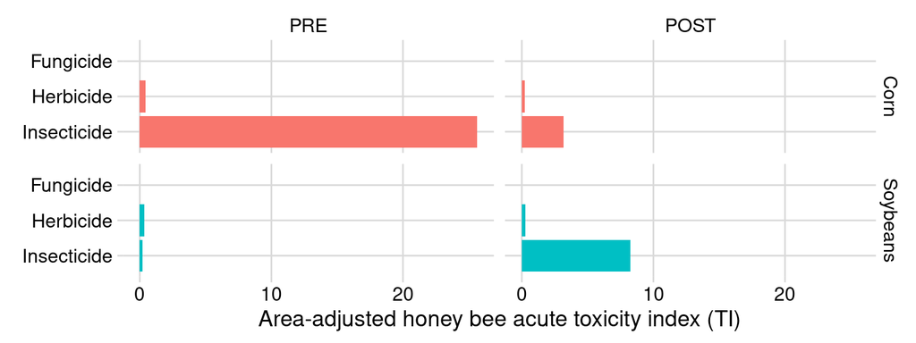

**Figure 1. Honey bee toxicity index applied before (PRE) or after (POST) crop emergence to corn or soybean during the period 1998 through 2020 by pesticide type.**

For both crops, a vast majority of *TI* was driven by insecticide usage, as expected, because insecticides are inherently more acutely toxic to insects, by design, compared to most herbicides and fungicides. In corn, insecticides were responsible for nearly 98% of *TI*. In soybean, insecticides were responsible for 93% of the total *TI*. In terms of total volume applied, herbicides are more heavily used in both corn and soybean; however, because *TI* accounts both for applied volume and inherent acute toxicity, the relative toxicity of insecticides to honey bees outweighs the greater herbicide usage in this metric. Because insecticides are the primary driver of overall acute risk to honey bees (and likely other pollinators), we will only discuss insecticides further in this manuscript. We will suggest, however, that future research aimed at chronic endpoints could provide nuanced insights into overall risk contributions from other groups of chemicals (like herbicides and fungicides).

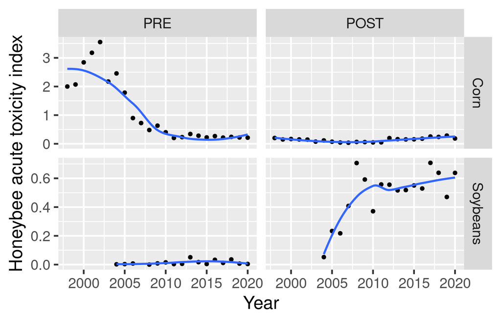

**Figure 2. Honey bee adult acute contact toxicity index for insecticides applied to corn or soybean before (PRE) or after (POST) crop emergence. Insecticide surveys for soybean began in 2004.**

In soybeans, insecticides were not surveyed by Kynetec in the FarmTrak Chemical Use survey before 2004. During the period 2005 to 2010, 99% of the insecticide *TI* resulted from applications after crop emergence, although the total insecticide *TI* was still comparatively low. More recently, between 2015 to 2020, 97% of soybean insecticide *TI* resulted from POST applications, and exceeded the insecticide *TI* associated with POST corn insecticide usage.

Two pesticides, fipronil and chlorpyrifos, were responsible for a majority of the total insecticide *TI* from PRE applications to corn until approximately 2010 (Figure 3A), when all uses of fipronil on corn were cancelled in the United States<sup>28</sup>. After 2010, bifenthrin became the largest contributor to *TI* in both PRE (Figure 3B) and POST (Figure 3C) application timings in corn. Insecticide *TI* resulting from PRE applications to soybeans remained low throughout the study period (Figure 2), and are thus not included in Figure 3. Insecticide applications were relatively uncommon in soybean before 2006, with annual average volume of less than 1 million kg applied dating back to 1994<sup>29</sup>, which helps to explain why they were not included in the Kynetec Chemical Use survey before 2004. Three insecticides (bifenthrin, chlorpyrifos, and lambda-cyhalothrin) accounted for a majority of the insecticide *TI* resulting from POST applications to soybean since 2006 (Figure 3D).

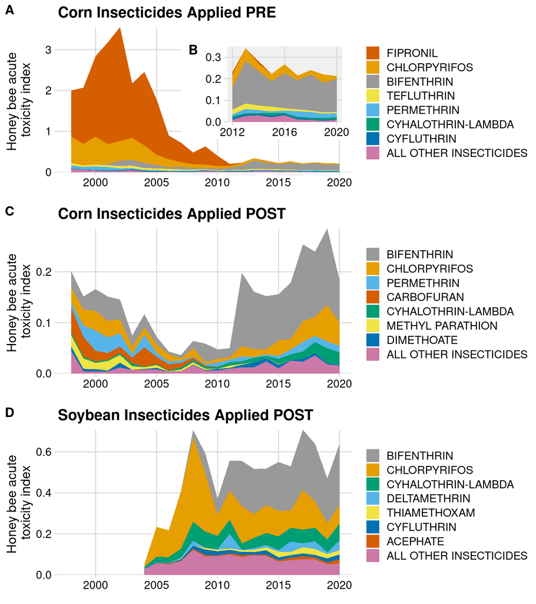

**Figure 3. Contribution of insecticide active ingredients to honey bee adult acute contact toxicity index applied PRE to corn (A, B), POST to corn (C), or POST to soybean (D). Panel B shows the period from 2012 to 2020 for corn PRE on a zoomed-in y-axis scale. The ‘All Other Insecticides’ category includes 2% of the total corn toxicity index applied PRE, 10% of the total corn toxicity index applied POST, and 13% of the total soybean toxicity index. Insecticide surveys for soybean began in 2004.**

## Impact of Pest Species on the Honey Bee Toxicity Index

In corn, insect pests from the orders Coleoptera and Lepidoptera contributed most to the overall insecticide *TI* (Figure 4), followed by Hemipteran insects and spider mites (Trombidiformes). In corn, there was a decreasing trend for Coleoptera (P < 0.001) and Lepidoptera (P < 0.001) contributions to the $TI_{pest}$ from 1998 through 2020. Hemiptera pests contribution to the insecticide *TI* increased over this time period (P = 0.001). There was also an increase in the contribution of the ‘Unknown’ pest target category (P < 0.001), which included survey responses that did not answer the question of which pest species was being targeted. Temporal trends for other taxa were not statistically significant in corn (Figure 4).

For more recent PRE applications in corn between 2015 through 2020, corn rootworm beetles, wireworms, and grubs were the largest contributors to the insecticide *TI* among Coleoptera pests, while cutworms of various species were the greatest contributors among Lepidopteran pests (Supplementary Table). Diptera had a relatively low contribution to the overall insecticide *TI* applied PRE, which is somewhat surprising since seedcorn maggot is considered a major pest in some corn growing regions. The insecticide *TI* resulting from POST applications in corn (Figure 4) was driven heavily by corn rootworm beetles (Coleoptera), Japanese beetles (Coleoptera), and stink bugs (Hemiptera), presumably due to potential for silk feeding. Aphids (Hemiptera) and cutworm species (Lepidoptera) were also important drivers of the corn insecticide *TI* from POST applications between 2015 through 2020.

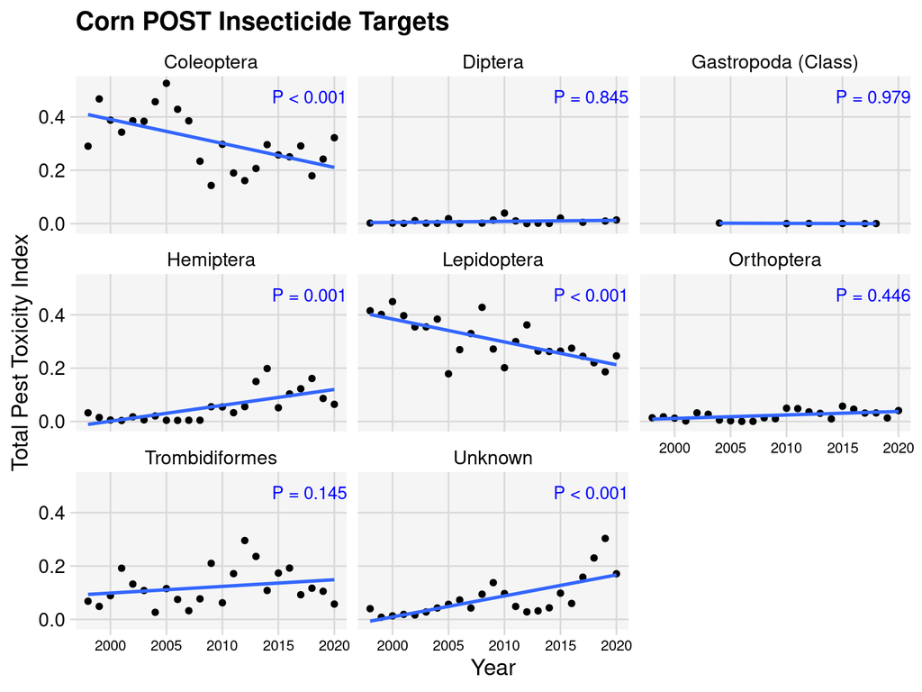

**Figure 4. Contribution of insect pests to the honey bee adult acute contact toxicity index; corn pesticides applied *after* crop emergence, 1998-2020.**

In soybean, Hemiptera pests were the greatest contributor to the insecticide *TI*, although there was a significant decrease in its contribution from 1998 through 2020 (P < 0.001). Stink bugs and aphid species were the greatest contributors to the insecticide *TI* among hemipteran pest species (Supplementary Table). Lepidopteran pest contribution to *TI* increased over time (P = 0.005). More recently, from 2015 through 2020, the Lepidoptera pests contributing most to the insecticide *TI* were various species referred to as ‘worms’ by survey respondents (including corn earworm and boll worm), ‘loopers’ (cabbage and soybean), and armyworms. Leaf beetles and Japanese beetles were the most impactful Coleoptera pest species in terms of contribution to the insecticide *TI* from POST applications to soybean between 2015 and 2020. Similar to corn, the ‘Unknown’ category also increased (P < 0.001) over the study period due to survey respondents not answering the question about the targeted pest(s).

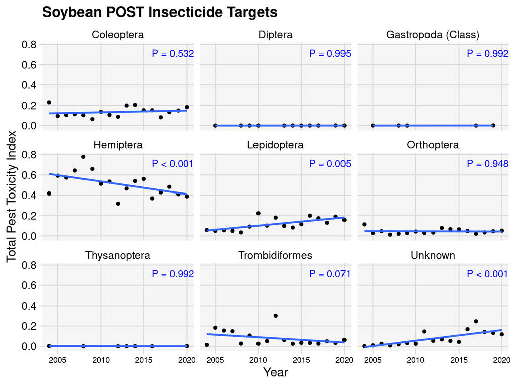

**Figure 5. Contribution of insect pests to the honey bee adult acute contact toxicity index; soybean pesticides applied *after* crop emergence, 1998-2020.**

## Insecticide Eco-Efficiency

The units associated with eco-efficiency (crop yield or value per unit of *TI*) are difficult to interpret in a practical way, but the trend over time provides insight into whether the observed increases in crop yield are out-pacing changes in hazard to honey bees from insecticides. Because both corn and soybean yield continued to increase throughout this period, the flat to declining trend in insecticide eco-efficiency in recent years suggests that the relative increase observed in the honey bee *TI* is out-pacing the relative increases in corn yields since 2012 on the national scale, even when adjusted for increases in the area of corn and soybeans grown.

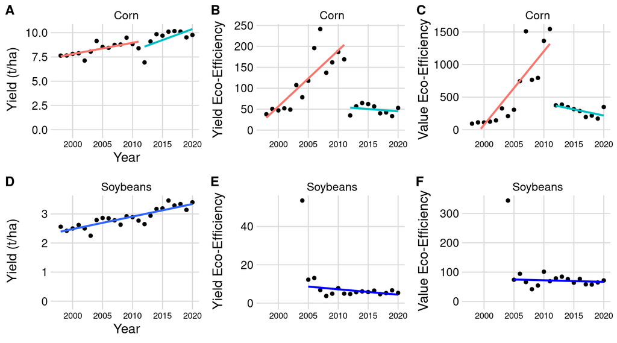

The eco-efficiency results reported here suggest that the honey bee hazard from recent insecticide usage in corn and soybean is increasing more rapidly than the yield gains observed over the same period. There has also been a shift for an increased honey bee insecticide hazard being applied after crop emergence when there is likely to be greater exposure potential to honey bees and other pollinators. In corn, the increased insecticide hazard applied after crop emergence has, perhaps, been somewhat offset by a relatively larger decrease in insecticide hazard applied before crop emergence. However, since pollinator presence in corn fields is undoubtedly greater after crop emergence, this trade-off is difficult to quantify. From a practical standpoint, if honey bee foraging occurs less in corn relative to other crops, that could reduce the real-world impact of the observed increase in hazard.

In soybeans, insecticide usage increased quickly after 2004 when the FarmTrak Chemical Use survey first included soybean insecticide applications. In more recent years (2015 to 2020), POST insecticide use in soybeans has resulted in a greater insecticide hazard to honey bees compared to corn. This uptick is not surprising, given the discovery of the invasive soybean aphid in 2000, and more recently, the emerging importance of plant bugs and stink bugs in soybeans, particularly in the Southern United States. However, this trend is especially concerning because soybeans are more attractive to pollinating bees for the collection of nectar than corn<sup>27</sup>. While corn pollen can be consumed by honey bees, overall visitation per hectare is likely to be much higher in soybeans when the crops are flowering.

In corn, the increased insecticide hazard applied after crop emergence has been offset by a substantial decrease in insecticide hazard applied before crop emergence, and therefore, the total hazard may be negligible. But in soybean, insecticide usage increased substantially after 2004<sup>29</sup> so that the POST insecticide hazard to honey bees was greater in soybeans than corn in the period 2015 to 2020. Soybeans are more attractive to pollinating bees for the collection of nectar than corn<sup>27</sup>. While corn pollen can be consumed, overall visitation per hectare is likely to be much higher in soybeans when the crops are flowering.

This analysis, like most others published before, does not include pesticides applied as seed treatments. Public data (such as USDA surveys and census data) as well as proprietary sources like the FarmTrak Chemical Use survey data do not include seed treatments. The impact of this data limitation is an underestimate of the hazard resulting from applications made PRE crop emergence; however, because honey bee exposure to pesticides applied as seed treatments is generally lower than those applied after crop emergence, the magnitude of this underestimate is difficult to ascertain. It is most commonly understood that with the exception of potential systemic insecticide movement in the crop plant, the greatest potential exposure from seed treatment use is at planting, when residues can ‘dust-off’ and drift to adjacent habitat that is attractive to bees. Industry has been making efforts to minimize dust-off potential with new planter and seed lubricant technology. But regardless, we emphasize that this exposure pathway is not part of our analysis.

It is also important to appropriately characterize exposure as a fundamental component to real-world risk. The *TI* in our analysis focuses on hazard, and does not quantitatively include exposure. This is important, because while insecticide *TI* values from PRE applications to corn are relatively high before 2010, the actual likelihood of bee exposure is negligible from many of those insecticide applications, particularly for active ingredients that are not systemic. Future research could evaluate impacts on non-target soil taxa and diversity, but flying insects that are present or foraging after crop emergence, the actual risk posed from even high *TI* active ingredients applied at before crop emergence could be widely negligible.

Broadly, it is important to understand *why* honey bee hazard from POST insecticide usage has been increasing in recent years. Is this increase due to a perceived increase in pest pressure, or a perceived increase in the economic damage caused by insect pests? Or perhaps the cost of certain pesticides has decreased, and consequently caused increased use as an economically viable, preemptive yield protection practice. While speculative, it is possible that the increased prevalence of ‘no answer’ in response to the target pest may be evidence for this possibility. Anecdotally, we are aware of cases where low-cost insecticides may be added in a tank-mixture to a planned fungicide or herbicide application because the grower is already spending significant costs to treat the field anyway. Such an approach may be rational in terms of a grower achieving cheap insurance against a pest outbreak; however, such applications may run counter to the fundamental principles of integrated pest management. Unless justified by other factors such as site history, local pest biology, or other evidence for high likelihood of an outbreak, integrated pest management typically dictates that application decisions should be driven by economic pest thresholds rather than precautionary or preventative treatments. We suggest that more research is needed to explore whether preventative insecticide applications are becoming more common, and what sorts of decision inputs are driving pest management decisions. The underlying cause of increased non-target hazards must be understood to develop research programs or devise policy actions that have a positive impact<sup>8</sup>.

To our knowledge, this analysis is the first to estimate the relative contribution of different pest species to non-target impacts of pesticide usage. The information gleaned from this approach provides multiple avenues for future research that could benefit non-target insect species like honey bees. For example, bifenthrin appears to be the active ingredient that has contributed most to recent increases in insecticide hazard to honey bees in both corn and soybean. At least for the usage where a target pest is reported, the pests that appear to drive bifenthrin usage include spider mites, corn rootworm, and Western bean cutworm in corn; and stink bugs and soybean aphids in soybean. We note that one limitation of the target pest data in the FarmTrak Chemical Use dataset is that tank-mix artifacts can arise. For example, if a grower is applying an insecticide and a miticide concurrently, FarmTrak data may associate mites with the insecticide if data for that specific active ingredient are pulled by target pest, even though it’s actually the miticide targeting mites. We suspect that some of the mite usage associated with pyrethroids (known in many cases to flare mites rather than control them) may be spurious for applications where miticides were tank-mixed. In any case, finding cost-effective efficacious pesticides with reduced non-target toxicity, or developing non-chemical approaches to manage these pests is ultimately crucial to reduce the overall non-target hazard from insecticide uses.

# References

1.

Kudsk, P., Jørgensen, L. N. & Ørum, J. E. [Pesticide Load—A new Danish pesticide risk indicator with multiple applications](https://doi.org/10.1016/j.landusepol.2017.11.010). *Land Use Policy* **70**, 384–393 (2018).

2.

Popp, J., Pető, K. & Nagy, J. [Pesticide productivity and food security. A review](https://doi.org/10.1007/s13593-012-0105-x). *Agronomy for Sustainable Development* **33**, 243–255 (2013).

3.

Tudi, M. *et al.* [Agriculture development, pesticide application and its impact on the environment](https://doi.org/10.3390/ijerph18031112). *International Journal of Environmental Research and Public Health* **18**, 1112 (2021).

4.

Fernandez-Cornejo, J. *et al.* Pesticide Use in U.S. Agriculture: 21 Selected Crops, 1960-2008. *SSRN Electronic Journal* (2014) doi:10.2139/ssrn.2502986.

5.

US EPA, O. Protecting Bees and Other Pollinators from Pesticides. (2013).

6.

USDA-NASS. *2022 Census of Agriculture*. 658 (2024).

7.

USDA-NASS. QuickStats Ad-hoc Query Tool. (2024).

8.

Osteen, C. D. & Fernandez-Cornejo, J. [Economic and policy issues of U.S. Agricultural pesticide use trends](https://doi.org/10.1002/ps.3529). *Pest Management Science* **69**, 1001–1025 (2013).

9.

Kniss, A. R. [Genetically engineered herbicide-resistant crops and herbicide-resistant weed evolution in the united states](https://doi.org/10.1017/wsc.2017.70). *Weed Science* **66**, 260–273 (2018).

10.

Kniss, A. R. [Long-term trends in the intensity and relative toxicity of herbicide use](https://doi.org/10.1038/ncomms14865). *Nature Communications* **8**, 14865 (2017).

11.

Benbrook, C. M. [Trends in glyphosate herbicide use in the United States and globally](https://doi.org/10.1186/s12302-016-0070-0). *Environmental Sciences Europe* **28**, 3 (2016).

12.

Kim, B. Y. & Kim, I.-J. [Worldwide patent trend analysis of herbicide-resistant genes](https://doi.org/10.1007/s11816-022-00783-9). *Plant Biotechnology Reports* **16**, 509–518 (2022).

13.

Boxall, A. B. A. *et al.* [Impacts of climate change on indirect human exposure to pathogens and chemicals from agriculture](https://doi.org/10.1289/ehp.0800084). *Environmental Health Perspectives* **117**, 508–514 (2009).

14.

Fisher, M. C. *et al.* [Emerging fungal threats to animal, plant and ecosystem health](https://doi.org/10.1038/nature10947). *Nature* **484**, 186–194 (2012).

15.

DiBartolomeis, M., Kegley, S., Mineau, P., Radford, R. & Klein, K. [An assessment of acute insecticide toxicity loading (AITL) of chemical pesticides used on agricultural land in the United States](https://doi.org/10.1371/journal.pone.0220029). *PLOS ONE* **14**, e0220029 (2019).

16.

Greitens, T. J. & Day, E. [An alternative way to evaluate the environmental effects of integrated pest management: Pesticide risk indicators](https://doi.org/10.1017/S1742170507001755). *Renewable Agriculture and Food Systems* **22**, 213–222 (2007).

17.

US EPA, O. Final Test Guidelines for Pesticides and Toxic Substances. (2015).

18.

US EPA, O. Learn About Models at EPA. (2015).

19.

Dushoff, J., Caldwell, B. & Mohler, C. L. [Evaluating the environmental effect of pesticides: A critique of the environmental impact quotient](https://doi.org/10.1093/ae/40.3.180). *American Entomologist* **40**, 180–184 (1994).

20.

Peterson, R. K. & Schleier, J. J. [A probabilistic analysis reveals fundamental limitations with the environmental impact quotient and similar systems for rating pesticide risks](https://doi.org/10.7717/peerj.364). *PeerJ* **2**, e364 (2014).

21.

Olker, J. H. *et al.* [The ECOTOXicology knowledgebase: A curated database of ecologically relevant toxicity tests to support environmental research and risk assessment](https://doi.org/10.1002/etc.5324). *Environmental Toxicology and Chemistry* **41**, 1520–1539 (2022).

22.

Farruggia, F. T. *et al.* [A retrospective analysis of honey bee (*Apis* *Mellifera*) pesticide toxicity data](https://doi.org/10.1371/journal.pone.0265962). *PLOS ONE* **17**, e0265962 (2022).

23.

Reilly, J. R. *et al.* [Crop production in the USA is frequently limited by a lack of pollinators](https://doi.org/10.1098/rspb.2020.0922). *Proceedings of the Royal Society B: Biological Sciences* **287**, 20200922 (2020).

24.

Goulson, D., Nicholls, E., Botías, C. & Rotheray, E. L. [Bee declines driven by combined stress from parasites, pesticides, and lack of flowers](https://doi.org/10.1126/science.1255957). *Science (New York, N.Y.)* **347**, 1255957 (2015).

25.

Johnson, R. M. [Honey bee toxicology](https://doi.org/10.1146/annurev-ento-011613-162005). *Annual Review of Entomology* **60**, 415–434 (2015).

26.

Arena, M. & Sgolastra, F. [A meta-analysis comparing the sensitivity of bees to pesticides](https://doi.org/10.1007/s10646-014-1190-1). *Ecotoxicology (London, England)* **23**, 324–334 (2014).

27.

USDA. *Attractiveness of Agricultural Crops to Pollinating Bees for the Collection of Nectar and/or Pollen*. 46 (2017).

28.

EPA, U. Fipronil; Product Cancellation Order and Amendment to Terminate Uses. *Federal Register* **75**, 5584–5585 (2010).

29.

Coupe, R. H. & Capel, P. D. [Trends in pesticide use on soybean, corn and cotton since the introduction of major genetically modified crops in the United States](https://doi.org/10.1002/ps.4082). *Pest Management Science* **72**, 1013–1022 (2016).

30.

Hammond, R. B., Michel, A. & Eisley, J. B. Soybean Aphid. *Ohio State University Extension Bulletin* **ENT-37**, (2014).

# Acknowledgements

The findings and conclusions in this publication are those of the authors and should not be construed to represent any official USDA or U.S. Government determination or policy. This work was supported by Cooperative Agreement 58-0111-21-003 from the USDA Office of the Chief Economist. We thank Dr. Joe Ballenger and Dr. Anastasia Bodnar for their role in developing this project idea, and we acknowledge Dr. Seth Wechsler for his leadership and ideas in the initial discussions about this work.

# Author Contributions

ARK, EA, CD, CM, CPJ, MR conceived and designed the research; ARK, ADS, EA compiled and analyzed the data; ARK, ADS, EA, CD, CM, CPJ, MR interpreted the data; ARK, ADS drafted the manuscript; EA, CD, CM, CPJ, MR revised and edited the manuscript. All authors approved the final version of the manuscript.

# Supplementary Information

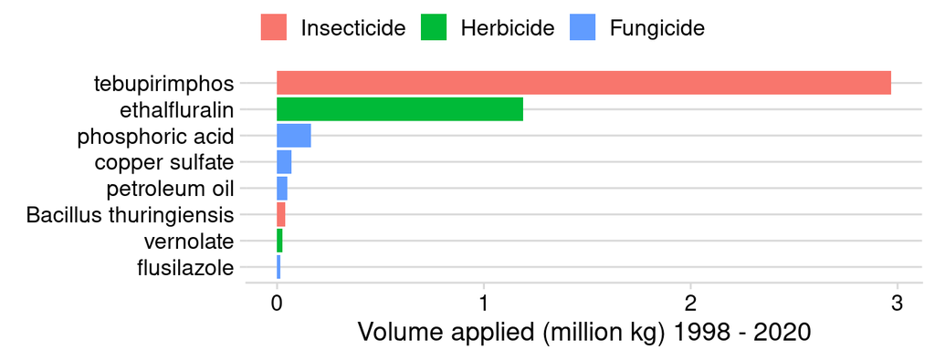

Supplementary Figure 1: Active ingredients applied at over 15,000 kg between 1998 through 2020 without reliable honey bee adult acute contact LD<sub>50</sub>.

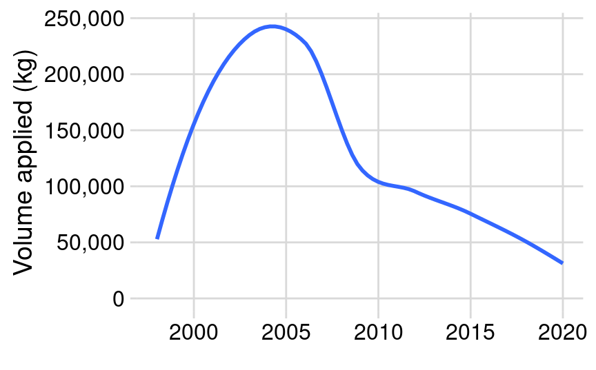

Supplementary Figure 2: Tebupirimphos usage in corn, 1998 to 2020.

**Supplementary Table 1. Pests reported by survey respondents since 2015 as the target for pesticides applied to corn and soybeans.**

| Crop | Application timing | Pest Order | Reported pest common name(s) | Percentage of Taxa |
| --- | --- | --- | --- | --- |
| Corn | POST | Coleoptera | Corn Rootworm (Mexican, Northern, Southern, Western) | 55 |
| Corn | POST | Coleoptera | Beetle, Japanese | 19 |
| Corn | POST | Coleoptera | Beetle (non-specific) | 9 |
| Corn | POST | Coleoptera | Beetle, Corn | 8 |
| Corn | POST | Hemiptera | Stink bug (brown marmorated, brown, green, redbanded, redshouldered, rice, southern green) | 64 |
| Corn | POST | Hemiptera | Aphid (bean, soybean, russian wheat, root, leaf, green peach, corn leaf black, bird cherry-oat) | 32 |
| Corn | POST | Lepidoptera | Cutworm (army, black, climbing, dingy, granulate, pale western, variegated, western bean, other) | 55 |
| Corn | POST | Lepidoptera | Worm (bag, boll, bud, clover, ear, horn, leaf, pin, rednecked peanut, split) | 17 |
| Corn | POST | Lepidoptera | European Corn Borer | 14 |
| Corn | POST | Lepidoptera | Armyworm (beet, fall southern, western yellow striped, yellowstripe) | 6 |
| Corn | POST | Lepidoptera | Worm (generic) | 5 |
| Corn | PRE | Coleoptera | Corn Rootworm (Mexican, Northern, Southern, Western) | 64 |
| Corn | PRE | Coleoptera | Wireworm | 18 |
| Corn | PRE | Coleoptera | Grub (white, other non-specific) | 15 |
| Corn | PRE | Hemiptera | Aphid (bean, soybean, russian wheat, root, leaf, green peach, corn leaf black, bird cherry-oat) | 45 |
| Corn | PRE | Hemiptera | Stink bug (brown marmorated, brown, green, redbanded, redshouldered, rice, southern green) | 27 |
| Corn | PRE | Hemiptera | Bug (non-specific) | 15 |
| Corn | PRE | Hemiptera | Chinch Bug | 11 |
| Corn | PRE | Lepidoptera | Cutworm (army, black, climbing, dingy, granulate, pale western, variegated, western bean, other) | 83 |
| Corn | PRE | Lepidoptera | European Corn Borer | 6 |
| Soybeans | POST | Coleoptera | Leaf Beetle (corn, bean, cereal) | 44 |
| Soybeans | POST | Coleoptera | Beetle, Japanese | 40 |
| Soybeans | POST | Coleoptera | Beetle (non-specific) | 7 |
| Soybeans | POST | Hemiptera | Stink bug (brown marmorated, brown, green, redbanded, redshouldered, rice, southern green) | 48 |
| Soybeans | POST | Hemiptera | Aphid (bean, soybean, russian wheat, root, leaf, green peach, corn leaf black, bird cherry-oat) | 47 |
| Soybeans | POST | Lepidoptera | Worm (bag, boll, bud, clover, ear, horn, leaf, pin, rednecked peanut, split) | 27 |
| Soybeans | POST | Lepidoptera | Looper (cabbage, soybean) | 20 |
| Soybeans | POST | Lepidoptera | Armyworm (beet, fall southern, western yellow striped, yellowstripe) | 14 |
| Soybeans | POST | Lepidoptera | Caterpillar (alfalfa, thistle, velvetbean, other non-specific) | 12 |
| Soybeans | POST | Lepidoptera | Green Cloverworm | 8 |
| Soybeans | POST | Lepidoptera | Worm (generic) | 8 |
| Soybeans | PRE | Coleoptera | Grub (white, other non-specific) | 44 |
| Soybeans | PRE | Coleoptera | Wireworm | 30 |
| Soybeans | PRE | Coleoptera | Leaf Beetle (corn, bean, cereal) | 9 |
| Soybeans | PRE | Coleoptera | Corn Rootworm (Mexican, Northern, Southern, Western) | 9 |
| Soybeans | PRE | Coleoptera | Beetle, Japanese | 8 |
| Soybeans | PRE | Hemiptera | Aphid (bean, soybean, russian wheat, root, leaf, green peach, corn leaf black, bird cherry-oat) | 84 |
| Soybeans | PRE | Hemiptera | False Chinch Bug | 8 |
| Soybeans | PRE | Lepidoptera | Cutworm (army, black, climbing, dingy, granulate, pale western, variegated, western bean, other) | 64 |
| Soybeans | PRE | Lepidoptera | Armyworm (beet, fall southern, western yellow striped, yellowstripe) | 12 |
| Soybeans | PRE | Lepidoptera | Caterpillar (alfalfa, thistle, velvetbean, other non-specific) | 12 |
| Soybeans | PRE | Lepidoptera | Worm (bag, boll, bud, clover, ear, horn, leaf, pin, rednecked peanut, split) | 6 |
| Soybeans | PRE | Lepidoptera | Worm (generic) | 6 |